# Homework 3

Berfin Aş

06 03 2022

# Question 8

This question involves the use of simple linear regression on the Auto data set.

```r
data("Auto")
head(Auto)
```

```
##   mpg cylinders displacement horsepower weight acceleration year origin
## 1  18         8          307        130   3504         12.0   70      1
## 2  15         8          350        165   3693         11.5   70      1
## 3  18         8          318        150   3436         11.0   70      1
## 4  16         8          304        150   3433         12.0   70      1
## 5  17         8          302        140   3449         10.5   70      1
## 6  15         8          429        198   4341         10.0   70      1
##                        name
## 1 chevrolet chevelle malibu
## 2         buick skylark 320
## 3        plymouth satellite
## 4             amc rebel sst
## 5               ford torino
## 6          ford galaxie 500
```

```r
auto <- read_csv("https://www.statlearning.com/s/Auto.csv")
```

## (a) Use the lm() function to perform a simple linear regression with mpg as the response and horsepower as the predictor. Use the summary() function to print the results.

```r
res_auto <- lm(mpg ~ horsepower, data = Auto)
summary(res_auto)
```

```
##
## Call:
## lm(formula = mpg ~ horsepower, data = Auto)
##
## Residuals:
##      Min       1Q   Median       3Q      Max
## -13.5710  -3.2592  -0.3435   2.7630  16.9240
##
## Coefficients:
##              Estimate Std. Error t value Pr(>|t|)
## (Intercept) 39.935861   0.717499   55.66   <2e-16 ***
## horsepower  -0.157845   0.006446  -24.49   <2e-16 ***
## ---
## Signif. codes:  0 '***' 0.001 '**' 0.01 '*' 0.05 '.' 0.1 ' ' 1
##
## Residual standard error: 4.906 on 390 degrees of freedom
## Multiple R-squared:  0.6059, Adjusted R-squared:  0.6049
## F-statistic: 599.7 on 1 and 390 DF,  p-value: < 2.2e-16
```

There is a relationship between the predictor and response since the P-value is less than 0.05 and we reject the null hypothesis. R-squared value shows that the predictor’s effect on the response is almost 61% and the relationship between mpg and the horsepower is negative.The negative relationship can also be seen in the plot below.

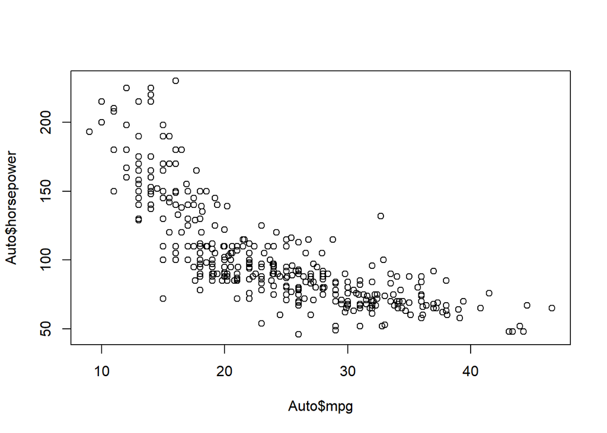

```r
plot(Auto$mpg, Auto$horsepower)
```

The confidence interval is;

```r
predict(res_auto, data.frame(horsepower = 98), interval = "confidence")
```

```
##        fit      lwr      upr
## 1 24.46708 23.97308 24.96108
```

The prediction interval is;

```r
predict(res_auto, data.frame(horsepower = 98), interval = "prediction")
```

```
##        fit     lwr      upr
## 1 24.46708 14.8094 34.12476
```

## (b) Plot the response and the predictor. Use the abline() function to display the least squares regression line.

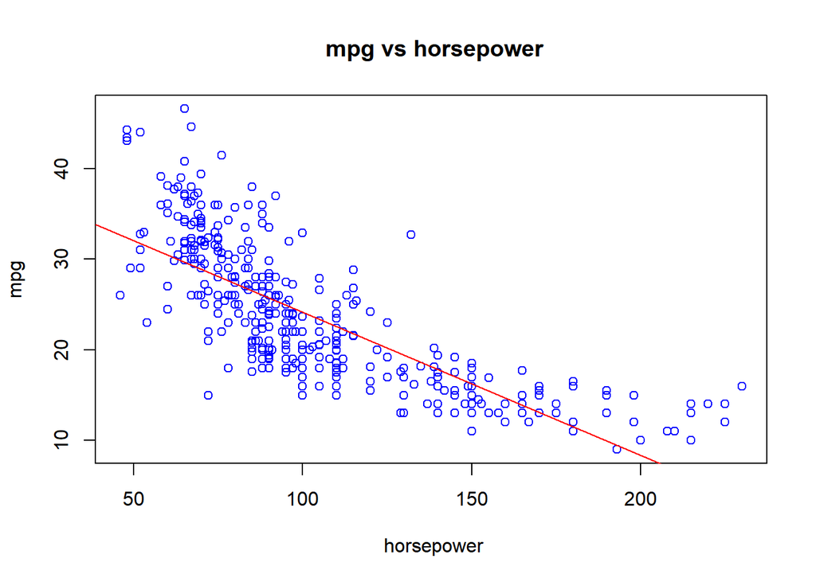

```r
plot(Auto$mp ~ Auto$horsepower, main =" mpg vs horsepower", xlab = " horsepower", ylab ="mpg", col = "blue")
abline(res_auto, col ="red")
```

## (c) Use the plot() function to produce diagnostic plots of the least squares regression fit. Comment on any problems you see with the fit.

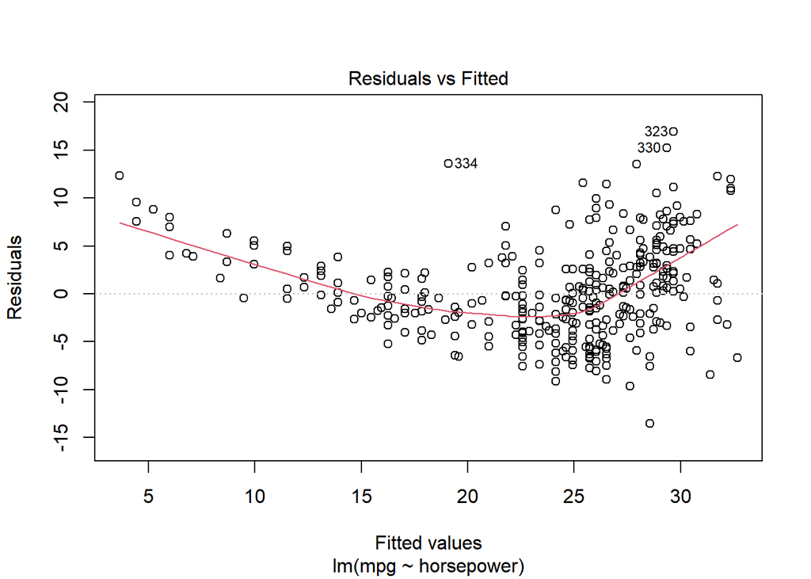

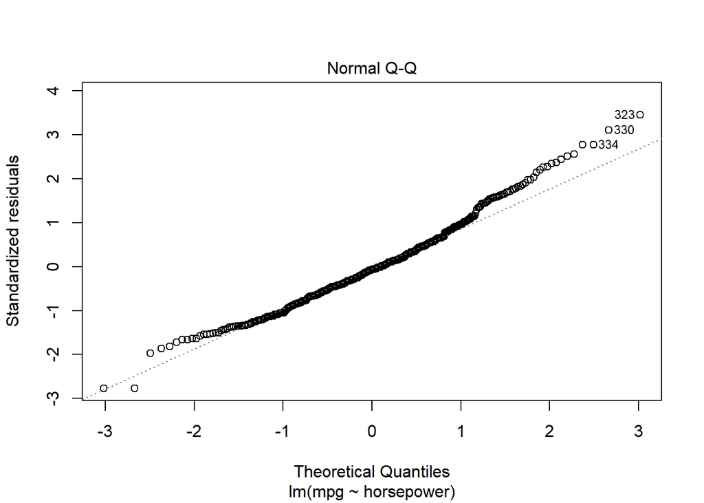

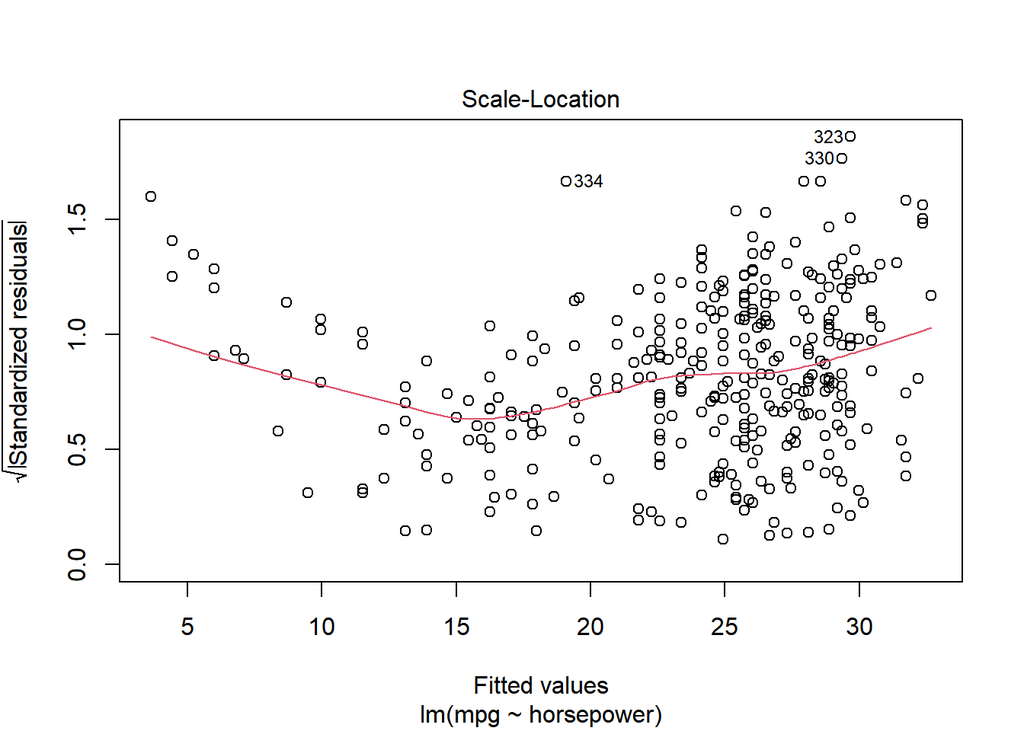

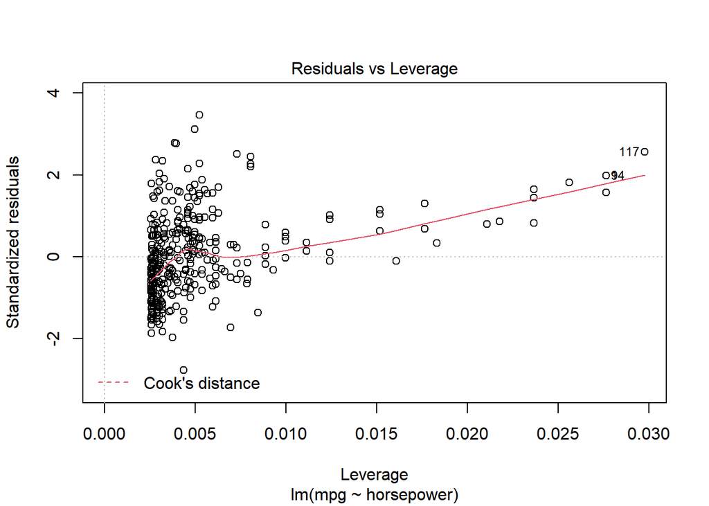

```r
plot(res_auto)
```

There is a non linear relationship between the residuals and the fitted values. The second plot indicates that the residuals are normally distributed.

# Question 9

This question involves the use of multiple linear regression on the Auto data set.

## (a) Produce a scatterplot matrix which includes all of the variables in the data set.

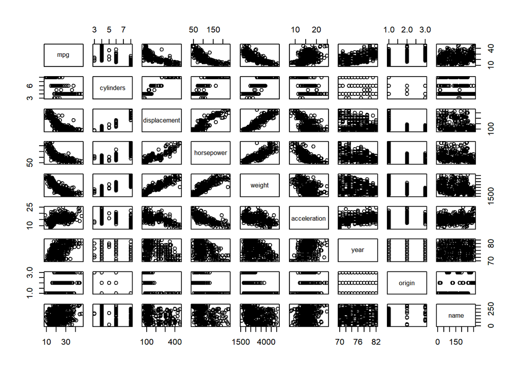

```r
plot(Auto)
```

## (b) Compute the matrix of correlations between the variables using the function cor(). You will need to exclude the name variable, which is qualitative.

```r
view(Auto)
```

Name is qualitative. Other columns are quantitative.

```r
cor(Auto[1:8])
```

```
##                     mpg  cylinders displacement horsepower     weight
## mpg           1.0000000 -0.7776175   -0.8051269 -0.7784268 -0.8322442
## cylinders    -0.7776175  1.0000000    0.9508233  0.8429834  0.8975273
## displacement -0.8051269  0.9508233    1.0000000  0.8972570  0.9329944
## horsepower   -0.7784268  0.8429834    0.8972570  1.0000000  0.8645377
## weight       -0.8322442  0.8975273    0.9329944  0.8645377  1.0000000
## acceleration  0.4233285 -0.5046834   -0.5438005 -0.6891955 -0.4168392
## year          0.5805410 -0.3456474   -0.3698552 -0.4163615 -0.3091199
## origin        0.5652088 -0.5689316   -0.6145351 -0.4551715 -0.5850054
##              acceleration       year     origin
## mpg             0.4233285  0.5805410  0.5652088
## cylinders      -0.5046834 -0.3456474 -0.5689316
## displacement   -0.5438005 -0.3698552 -0.6145351
## horsepower     -0.6891955 -0.4163615 -0.4551715
## weight         -0.4168392 -0.3091199 -0.5850054
## acceleration    1.0000000  0.2903161  0.2127458
## year            0.2903161  1.0000000  0.1815277
## origin          0.2127458  0.1815277  1.0000000
```

## (c) Use the lm() function to perform a multiple linear regression with mpg as the response and all other variables except name as the predictors. Use the summary() function to print the results. Comment on the output.

```r
res_auto <- lm(mpg ~. -name  , data=Auto)
summary(res_auto)
```

```
##
## Call:
## lm(formula = mpg ~ . - name, data = Auto)
##
## Residuals:
##     Min      1Q  Median      3Q     Max
## -9.5903 -2.1565 -0.1169  1.8690 13.0604
##
## Coefficients:
##                Estimate Std. Error t value Pr(>|t|)
## (Intercept)  -17.218435   4.644294  -3.707  0.00024 ***
## cylinders     -0.493376   0.323282  -1.526  0.12780
## displacement   0.019896   0.007515   2.647  0.00844 **
## horsepower    -0.016951   0.013787  -1.230  0.21963
## weight        -0.006474   0.000652  -9.929  < 2e-16 ***
## acceleration   0.080576   0.098845   0.815  0.41548
## year           0.750773   0.050973  14.729  < 2e-16 ***
## origin         1.426141   0.278136   5.127 4.67e-07 ***
## ---
## Signif. codes:  0 '***' 0.001 '**' 0.01 '*' 0.05 '.' 0.1 ' ' 1
##
## Residual standard error: 3.328 on 384 degrees of freedom
## Multiple R-squared:  0.8215, Adjusted R-squared:  0.8182
## F-statistic: 252.4 on 7 and 384 DF,  p-value: < 2.2e-16
```

There is a relationship between the predictors and the response. Displacement, year, weight and origin appear to have a statistically significant relationship to the response (P-value < 0.05). The coefficient for the year variable suggests that there is a positive relationship between year and mpg given that other predictors are constant.

## (d) Use the plot() function to produce diagnostic plots of the linear regression fit. Comment on any problems you see with the fit. Do the residual plots suggest any unusually large outliers? Does the leverage plot identify any observations with unusually high leverage?

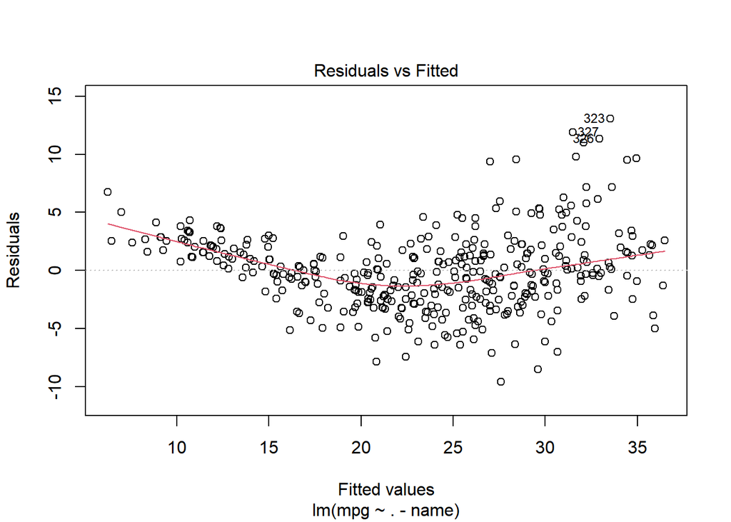

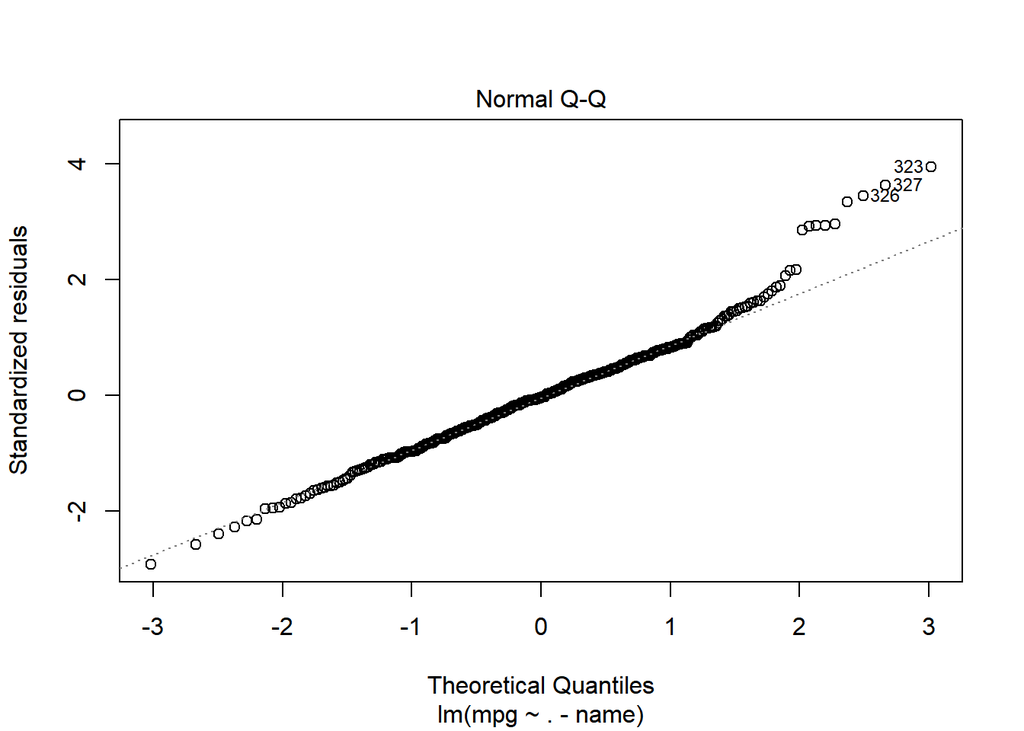

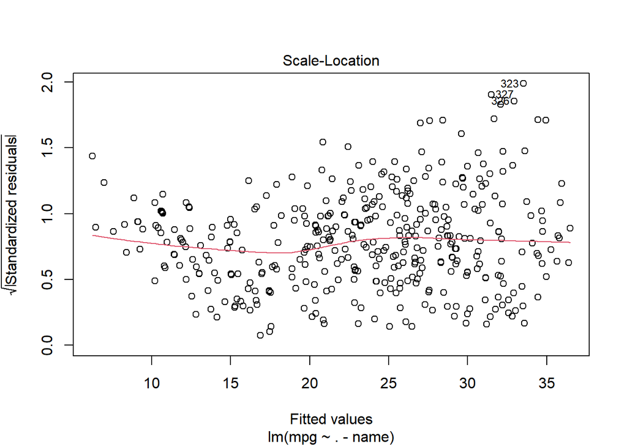

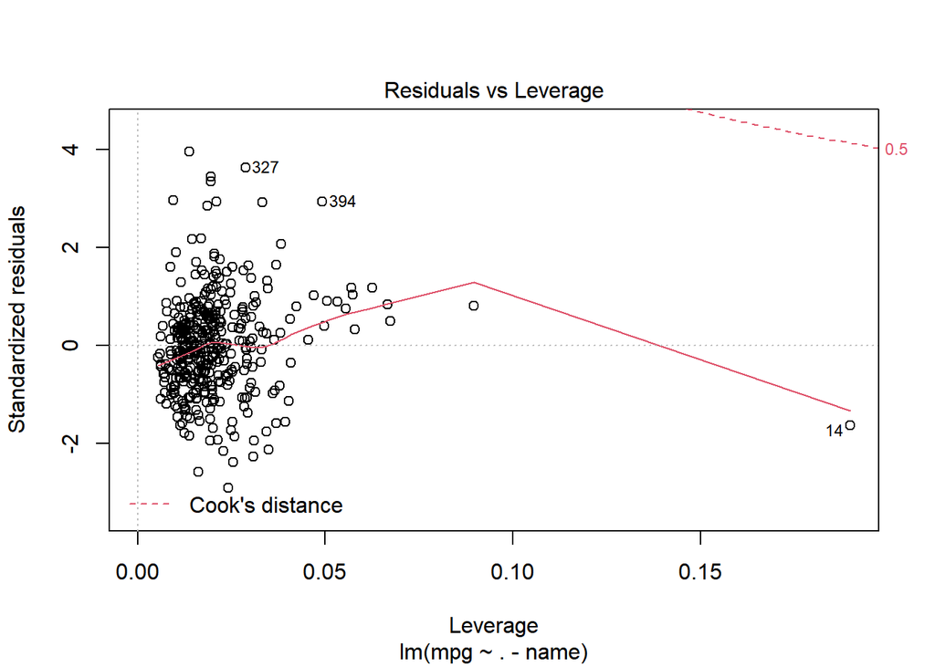

```r
plot(res_auto)
```

## (e) Use the * and : symbols to fit linear regression models with interaction effects. Do any interactions appear to be statistically significant?

```r
res_auto3 <- lm(mpg ~ displacement*acceleration + horsepower*acceleration, data = Auto)
summary(res_auto3)
```

```
##
## Call:
## lm(formula = mpg ~ displacement * acceleration + horsepower *
##     acceleration, data = Auto)
##
## Residuals:
##      Min       1Q   Median       3Q      Max
## -11.3351  -2.5711  -0.2208   2.0152  16.4724
##
## Coefficients:
##                            Estimate Std. Error t value Pr(>|t|)
## (Intercept)               27.304478   3.355668   8.137 5.63e-15 ***
## displacement              -0.017203   0.027136  -0.634  0.52648
## acceleration               0.991219   0.203538   4.870 1.63e-06 ***
## horsepower                 0.077253   0.066101   1.169  0.24324
## displacement:acceleration -0.001306   0.001732  -0.754  0.45113
## acceleration:horsepower   -0.013057   0.004282  -3.049  0.00245 **
## ---
## Signif. codes:  0 '***' 0.001 '**' 0.01 '*' 0.05 '.' 0.1 ' ' 1
##
## Residual standard error: 4.1 on 386 degrees of freedom
## Multiple R-squared:  0.7275, Adjusted R-squared:  0.724
## F-statistic: 206.1 on 5 and 386 DF,  p-value: < 2.2e-16
```

According to this model, it can be said that the interaction between acceleration and horsepower is statistically significant, while the interaction between displacement and acceleration is not significant by looking at their p-values.

## (f) Try a few different transformations of the variables, such as log(X), √X, X2. Comment on your findings.

```r
res_auto3 = lm(mpg~log(weight)+sqrt(horsepower)+acceleration+I(acceleration^2), data = Auto)
summary(res_auto3)
```

```
##
## Call:
## lm(formula = mpg ~ log(weight) + sqrt(horsepower) + acceleration +
##     I(acceleration^2), data = Auto)
##
## Residuals:
##      Min       1Q   Median       3Q      Max
## -11.2932  -2.5082  -0.2237   2.0237  15.7650
##
## Coefficients:
##                    Estimate Std. Error t value Pr(>|t|)
## (Intercept)       178.30303   10.80451  16.503  < 2e-16 ***
## log(weight)       -14.74259    1.73994  -8.473 5.06e-16 ***
## sqrt(horsepower)   -1.85192    0.36005  -5.144 4.29e-07 ***
## acceleration       -2.19890    0.63903  -3.441 0.000643 ***
## I(acceleration^2)   0.06139    0.01857   3.305 0.001037 **
## ---
## Signif. codes:  0 '***' 0.001 '**' 0.01 '*' 0.05 '.' 0.1 ' ' 1
##
## Residual standard error: 3.99 on 387 degrees of freedom
## Multiple R-squared:  0.7414, Adjusted R-squared:  0.7387
## F-statistic: 277.3 on 4 and 387 DF,  p-value: < 2.2e-16
```

It can be said that log(weight), sqrt(horsepower), acceleration and I(acceleration^2) have statistically significant effect on mpg.

# Question 10

This question should be answered using the Carseats data set.

```r
data("Carseats")
head(Carseats)
```

```
##   Sales CompPrice Income Advertising Population Price ShelveLoc Age Education
## 1  9.50       138     73          11        276   120       Bad  42        17
## 2 11.22       111     48          16        260    83      Good  65        10
## 3 10.06       113     35          10        269    80    Medium  59        12
## 4  7.40       117    100           4        466    97    Medium  55        14
## 5  4.15       141     64           3        340   128       Bad  38        13
## 6 10.81       124    113          13        501    72       Bad  78        16
##   Urban  US
## 1   Yes Yes
## 2   Yes Yes
## 3   Yes Yes
## 4   Yes Yes
## 5   Yes  No
## 6    No Yes
```

## (a) Fit a multiple regression model to predict Sales using Price, Urban, and US.

```r
res_carseats <- lm(Sales ~ Price + Urban + US, data = Carseats)
summary(res_carseats)
```

```
##
## Call:
## lm(formula = Sales ~ Price + Urban + US, data = Carseats)
##
## Residuals:
##     Min      1Q  Median      3Q     Max
## -6.9206 -1.6220 -0.0564  1.5786  7.0581
##
## Coefficients:
##              Estimate Std. Error t value Pr(>|t|)
## (Intercept) 13.043469   0.651012  20.036  < 2e-16 ***
## Price       -0.054459   0.005242 -10.389  < 2e-16 ***
## UrbanYes    -0.021916   0.271650  -0.081    0.936
## USYes        1.200573   0.259042   4.635 4.86e-06 ***
## ---
## Signif. codes:  0 '***' 0.001 '**' 0.01 '*' 0.05 '.' 0.1 ' ' 1
##
## Residual standard error: 2.472 on 396 degrees of freedom
## Multiple R-squared:  0.2393, Adjusted R-squared:  0.2335
## F-statistic: 41.52 on 3 and 396 DF,  p-value: < 2.2e-16
```

## (b) Provide an interpretation of each coefficient in the model. Be careful—some of the variables in the model are qualitative!

```r
view(Carseats)
```

Urban and US are qualitative.

By looking at the P-values, it can be said that Price and $US_{Yes}$ (indicates that the store is in the US) have statistically significant effects on Sales.

There is a negative relationship between Price and Sales. This means that if the prices go up, sales go down.

There is a positive relationship between $US_{Yes}$ and Sales. This means that sales are higher in the US than other places.

## (c) Write out the model in equation form, being careful to handle the qualitative variables properly.

```r
coefs <- round(coef(res_carseats), digits = 2)
```

$$Sales = \beta_{0} + \beta_{1}*Price + \beta_{2}*Urban_{Yes} + \beta_{3}*US_{Yes} + \varepsilon$$

$$Sales = 13.04 - 0.05*Price - 0.02*Urban_{Yes} + 1.2*US_{Yes}$$

## (d) For which of the predictors can you reject the null hypothesis H0 : βj = 0?

```r
summary(res_carseats)
```

```
##
## Call:
## lm(formula = Sales ~ Price + Urban + US, data = Carseats)
##
## Residuals:
##     Min      1Q  Median      3Q     Max
## -6.9206 -1.6220 -0.0564  1.5786  7.0581
##
## Coefficients:
##              Estimate Std. Error t value Pr(>|t|)
## (Intercept) 13.043469   0.651012  20.036  < 2e-16 ***
## Price       -0.054459   0.005242 -10.389  < 2e-16 ***
## UrbanYes    -0.021916   0.271650  -0.081    0.936
## USYes        1.200573   0.259042   4.635 4.86e-06 ***
## ---
## Signif. codes:  0 '***' 0.001 '**' 0.01 '*' 0.05 '.' 0.1 ' ' 1
##
## Residual standard error: 2.472 on 396 degrees of freedom
## Multiple R-squared:  0.2393, Adjusted R-squared:  0.2335
## F-statistic: 41.52 on 3 and 396 DF,  p-value: < 2.2e-16
```

We reject the null hypothesis when the P-value is less than 0.05. In this case, we reject the null hypothesis for Price and $US_{Yes}$ predictors.

## (e) On the basis of your response to the previous question, fit a smaller model that only uses the predictors for which there is evidence of association with the outcome.

Since Price and $US_{Yes}$ have an effect on the outcome, I chose them.

```r
res_carseats2 <- lm(Sales ~ Price + US, data = Carseats)
summary(res_carseats2)
```

```
##
## Call:
## lm(formula = Sales ~ Price + US, data = Carseats)
##
## Residuals:
##     Min      1Q  Median      3Q     Max
## -6.9269 -1.6286 -0.0574  1.5766  7.0515
##
## Coefficients:
##             Estimate Std. Error t value Pr(>|t|)
## (Intercept) 13.03079    0.63098  20.652  < 2e-16 ***
## Price       -0.05448    0.00523 -10.416  < 2e-16 ***
## USYes        1.19964    0.25846   4.641 4.71e-06 ***
## ---
## Signif. codes:  0 '***' 0.001 '**' 0.01 '*' 0.05 '.' 0.1 ' ' 1
##
## Residual standard error: 2.469 on 397 degrees of freedom
## Multiple R-squared:  0.2393, Adjusted R-squared:  0.2354
## F-statistic: 62.43 on 2 and 397 DF,  p-value: < 2.2e-16
```

## (g) Using the model from (e), obtain 95% confidence intervals for the coefficient(s).

The confidence interval is;

```r
confint(res_carseats2, level = 0.95)
```

```
##                   2.5 %      97.5 %
## (Intercept) 11.79032020 14.27126531
## Price       -0.06475984 -0.04419543
## USYes        0.69151957  1.70776632
```

## (h) Is there evidence of outliers or high leverage observations in the model from (e)?

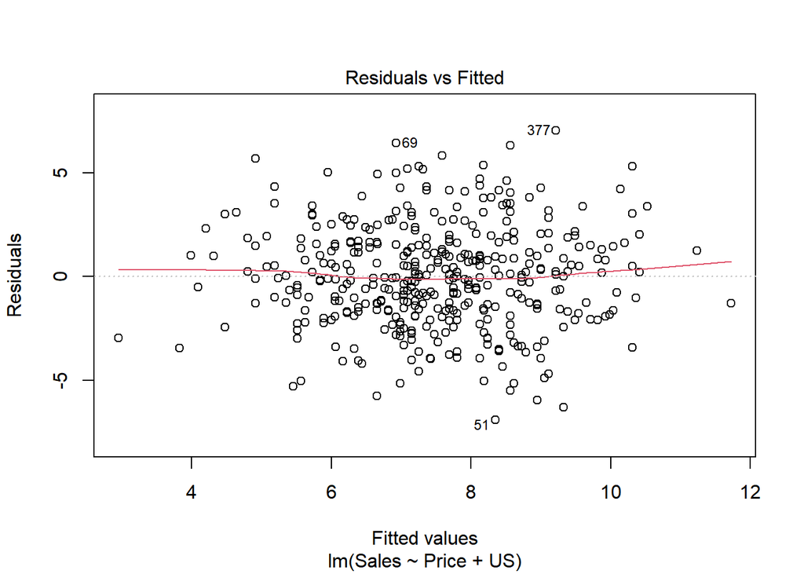

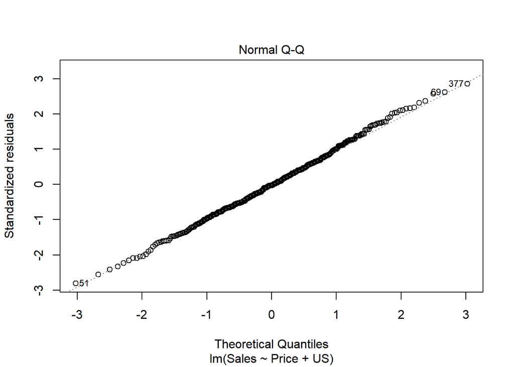

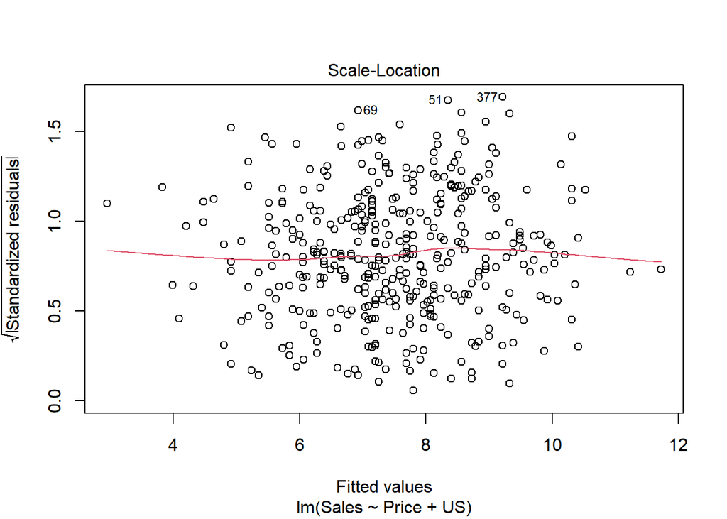

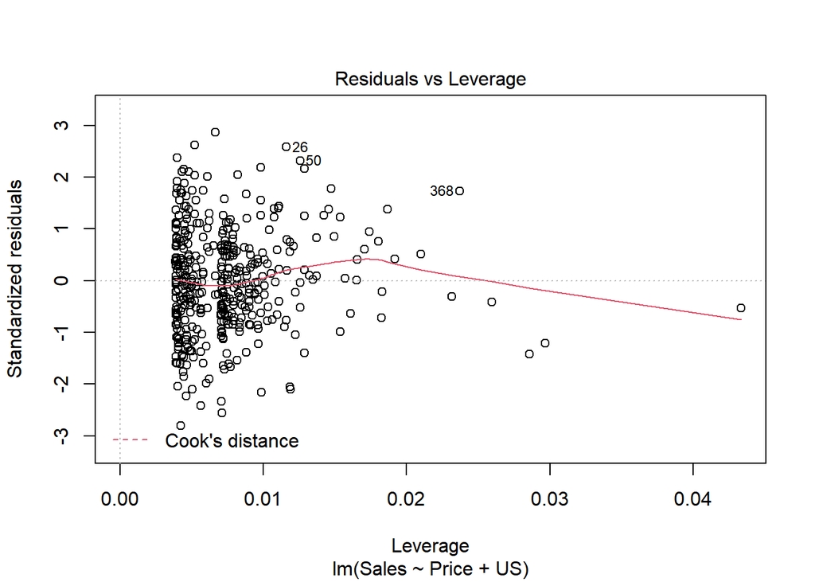

```r
plot(res_carseats2)
```